# data_manipulation

Name: **Ryan Essem**

## Section 1: Working with Pandas

For this section, we will use the files in the folder named `gapminder` that is inside the `data` folder. These files contain the *per capita* GDP for countries within various regions of the world. The file name indicates which region the data belongs to.

**Within each section the questions guide you to a final analysis. You should not re-import the data unless intructed.**

### Q1) Import the files.

Import the files `gapminder_gdp_americas.csv` and `gapminder_gdp_europe.csv` and save them into dataframes named `americas_df` and `europe_df` respectively. In both dataframes, make *country* the index. Make sure that you use **relative** paths.

```python
import glob
import pandas as pd
```

```python
path = 'data/gapminder/' #relative path

all_files = glob.glob(path + "/*.csv") #find all files in the rel path that are denoted as csv
all_files
```

```
['data/gapminder/gapminder_gdp_americas.csv',
 'data/gapminder/gapminder_gdp_europe.csv',
 'data/gapminder/gapminder_gdp_oceania.csv',
 'data/gapminder/gapminder_gdp_africa.csv',
 'data/gapminder/gapminder_gdp_asia.csv']
```

```python
#read csv, and set index
gapminder_usa =  glob.glob(path + "gapminder_gdp_americas.csv")
americas_df = pd.read_csv(gapminder_usa[0])
americas_df.set_index('country', inplace=True)
americas_df
```

| country | continent | gdpPercap_1952 | gdpPercap_1957 | gdpPercap_1962 | gdpPercap_1967 | gdpPercap_1972 | gdpPercap_1977 | gdpPercap_1982 | gdpPercap_1987 | gdpPercap_1992 | gdpPercap_1997 | gdpPercap_2002 | gdpPercap_2007 |
| --- | --- | --- | --- | --- | --- | --- | --- | --- | --- | --- | --- | --- | --- |
| Argentina | Americas | 5911.315053 | 6856.856212 | 7133.166023 | 8052.953021 | 9443.038526 | 10079.026740 | 8997.897412 | 9139.671389 | 9308.418710 | 10967.281950 | 8797.640716 | 12779.379640 |
| Bolivia | Americas | 2677.326347 | 2127.686326 | 2180.972546 | 2586.886053 | 2980.331339 | 3548.097832 | 3156.510452 | 2753.691490 | 2961.699694 | 3326.143191 | 3413.262690 | 3822.137084 |
| Brazil | Americas | 2108.944355 | 2487.365989 | 3336.585802 | 3429.864357 | 4985.711467 | 6660.118654 | 7030.835878 | 7807.095818 | 6950.283021 | 7957.980824 | 8131.212843 | 9065.800825 |
| Canada | Americas | 11367.161120 | 12489.950060 | 13462.485550 | 16076.588030 | 18970.570860 | 22090.883060 | 22898.792140 | 26626.515030 | 26342.884260 | 28954.925890 | 33328.965070 | 36319.235010 |
| Chile | Americas | 3939.978789 | 4315.622723 | 4519.094331 | 5106.654313 | 5494.024437 | 4756.763836 | 5095.665738 | 5547.063754 | 7596.125964 | 10118.053180 | 10778.783850 | 13171.638850 |
| Colombia | Americas | 2144.115096 | 2323.805581 | 2492.351109 | 2678.729839 | 3264.660041 | 3815.807870 | 4397.575659 | 4903.219100 | 5444.648617 | 6117.361746 | 5755.259962 | 7006.580419 |
| Costa Rica | Americas | 2627.009471 | 2990.010802 | 3460.937025 | 4161.727834 | 5118.146939 | 5926.876967 | 5262.734751 | 5629.915318 | 6160.416317 | 6677.045314 | 7723.447195 | 9645.061420 |
| Cuba | Americas | 5586.538780 | 6092.174359 | 5180.755910 | 5690.268015 | 5305.445256 | 6380.494966 | 7316.918107 | 7532.924763 | 5592.843963 | 5431.990415 | 6340.646683 | 8948.102923 |
| Dominican Republic | Americas | 1397.717137 | 1544.402995 | 1662.137359 | 1653.723003 | 2189.874499 | 2681.988900 | 2861.092386 | 2899.842175 | 3044.214214 | 3614.101285 | 4563.808154 | 6025.374752 |
| Ecuador | Americas | 3522.110717 | 3780.546651 | 4086.114078 | 4579.074215 | 5280.994710 | 6679.623260 | 7213.791267 | 6481.776993 | 7103.702595 | 7429.455877 | 5773.044512 | 6873.262326 |
| El Salvador | Americas | 3048.302900 | 3421.523218 | 3776.803627 | 4358.595393 | 4520.246008 | 5138.922374 | 4098.344175 | 4140.442097 | 4444.231700 | 5154.825496 | 5351.568666 | 5728.353514 |
| Guatemala | Americas | 2428.237769 | 2617.155967 | 2750.364446 | 3242.531147 | 4031.408271 | 4879.992748 | 4820.494790 | 4246.485974 | 4439.450840 | 4684.313807 | 4858.347495 | 5186.050003 |
| Haiti | Americas | 1840.366939 | 1726.887882 | 1796.589032 | 1452.057666 | 1654.456946 | 1874.298931 | 2011.159549 | 1823.015995 | 1456.309517 | 1341.726931 | 1270.364932 | 1201.637154 |
| Honduras | Americas | 2194.926204 | 2220.487682 | 2291.156835 | 2538.269358 | 2529.842345 | 3203.208066 | 3121.760794 | 3023.096699 | 3081.694603 | 3160.454906 | 3099.728660 | 3548.330846 |
| Jamaica | Americas | 2898.530881 | 4756.525781 | 5246.107524 | 6124.703451 | 7433.889293 | 6650.195573 | 6068.051350 | 6351.237495 | 7404.923685 | 7121.924704 | 6994.774861 | 7320.880262 |
| Mexico | Americas | 3478.125529 | 4131.546641 | 4581.609385 | 5754.733883 | 6809.406690 | 7674.929108 | 9611.147541 | 8688.156003 | 9472.384295 | 9767.297530 | 10742.440530 | 11977.574960 |
| Nicaragua | Americas | 3112.363948 | 3457.415947 | 3634.364406 | 4643.393534 | 4688.593267 | 5486.371089 | 3470.338156 | 2955.984375 | 2170.151724 | 2253.023004 | 2474.548819 | 2749.320965 |
| Panama | Americas | 2480.380334 | 2961.800905 | 3536.540301 | 4421.009084 | 5364.249663 | 5351.912144 | 7009.601598 | 7034.779161 | 6618.743050 | 7113.692252 | 7356.031934 | 9809.185636 |
| Paraguay | Americas | 1952.308701 | 2046.154706 | 2148.027146 | 2299.376311 | 2523.337977 | 3248.373311 | 4258.503604 | 3998.875695 | 4196.411078 | 4247.400261 | 3783.674243 | 4172.838464 |
| Peru | Americas | 3758.523437 | 4245.256698 | 4957.037982 | 5788.093330 | 5937.827283 | 6281.290855 | 6434.501797 | 6360.943444 | 4446.380924 | 5838.347657 | 5909.020073 | 7408.905561 |
| Puerto Rico | Americas | 3081.959785 | 3907.156189 | 5108.344630 | 6929.277714 | 9123.041742 | 9770.524921 | 10330.989150 | 12281.341910 | 14641.587110 | 16999.433300 | 18855.606180 | 19328.709010 |
| Trinidad and Tobago | Americas | 3023.271928 | 4100.393400 | 4997.523971 | 5621.368472 | 6619.551419 | 7899.554209 | 9119.528607 | 7388.597823 | 7370.990932 | 8792.573126 | 11460.600230 | 18008.509240 |
| United States | Americas | 13990.482080 | 14847.127120 | 16173.145860 | 19530.365570 | 21806.035940 | 24072.632130 | 25009.559140 | 29884.350410 | 32003.932240 | 35767.433030 | 39097.099550 | 42951.653090 |
| Uruguay | Americas | 5716.766744 | 6150.772969 | 5603.357717 | 5444.619620 | 5703.408898 | 6504.339663 | 6920.223051 | 7452.398969 | 8137.004775 | 9230.240708 | 7727.002004 | 10611.462990 |
| Venezuela | Americas | 7689.799761 | 9802.466526 | 8422.974165 | 9541.474188 | 10505.259660 | 13143.950950 | 11152.410110 | 9883.584648 | 10733.926310 | 10165.495180 | 8605.047831 | 11415.805690 |

```python
#read csv, and set index

gapminder_eu =  glob.glob(path + "gapminder_gdp_europe.csv")
europe_df = pd.read_csv(gapminder_eu[0])
europe_df.set_index('country', inplace=True)
europe_df
```

| country | gdpPercap_1952 | gdpPercap_1957 | gdpPercap_1962 | gdpPercap_1967 | gdpPercap_1972 | gdpPercap_1977 | gdpPercap_1982 | gdpPercap_1987 | gdpPercap_1992 | gdpPercap_1997 | gdpPercap_2002 | gdpPercap_2007 |
| --- | --- | --- | --- | --- | --- | --- | --- | --- | --- | --- | --- | --- |
| Albania | 1601.056136 | 1942.284244 | 2312.888958 | 2760.196931 | 3313.422188 | 3533.003910 | 3630.880722 | 3738.932735 | 2497.437901 | 3193.054604 | 4604.211737 | 5937.029526 |
| Austria | 6137.076492 | 8842.598030 | 10750.721110 | 12834.602400 | 16661.625600 | 19749.422300 | 21597.083620 | 23687.826070 | 27042.018680 | 29095.920660 | 32417.607690 | 36126.492700 |
| Belgium | 8343.105127 | 9714.960623 | 10991.206760 | 13149.041190 | 16672.143560 | 19117.974480 | 20979.845890 | 22525.563080 | 25575.570690 | 27561.196630 | 30485.883750 | 33692.605080 |
| Bosnia and Herzegovina | 973.533195 | 1353.989176 | 1709.683679 | 2172.352423 | 2860.169750 | 3528.481305 | 4126.613157 | 4314.114757 | 2546.781445 | 4766.355904 | 6018.975239 | 7446.298803 |
| Bulgaria | 2444.286648 | 3008.670727 | 4254.337839 | 5577.002800 | 6597.494398 | 7612.240438 | 8224.191647 | 8239.854824 | 6302.623438 | 5970.388760 | 7696.777725 | 10680.792820 |
| Croatia | 3119.236520 | 4338.231617 | 5477.890018 | 6960.297861 | 9164.090127 | 11305.385170 | 13221.821840 | 13822.583940 | 8447.794873 | 9875.604515 | 11628.388950 | 14619.222720 |
| Czech Republic | 6876.140250 | 8256.343918 | 10136.867130 | 11399.444890 | 13108.453600 | 14800.160620 | 15377.228550 | 16310.443400 | 14297.021220 | 16048.514240 | 17596.210220 | 22833.308510 |
| Denmark | 9692.385245 | 11099.659350 | 13583.313510 | 15937.211230 | 18866.207210 | 20422.901500 | 21688.040480 | 25116.175810 | 26406.739850 | 29804.345670 | 32166.500060 | 35278.418740 |
| Finland | 6424.519071 | 7545.415386 | 9371.842561 | 10921.636260 | 14358.875900 | 15605.422830 | 18533.157610 | 21141.012230 | 20647.164990 | 23723.950200 | 28204.590570 | 33207.084400 |
| France | 7029.809327 | 8662.834898 | 10560.485530 | 12999.917660 | 16107.191710 | 18292.635140 | 20293.897460 | 22066.442140 | 24703.796150 | 25889.784870 | 28926.032340 | 30470.016700 |
| Germany | 7144.114393 | 10187.826650 | 12902.462910 | 14745.625610 | 18016.180270 | 20512.921230 | 22031.532740 | 24639.185660 | 26505.303170 | 27788.884160 | 30035.801980 | 32170.374420 |
| Greece | 3530.690067 | 4916.299889 | 6017.190733 | 8513.097016 | 12724.829570 | 14195.524280 | 15268.420890 | 16120.528390 | 17541.496340 | 18747.698140 | 22514.254800 | 27538.411880 |
| Hungary | 5263.673816 | 6040.180011 | 7550.359877 | 9326.644670 | 10168.656110 | 11674.837370 | 12545.990660 | 12986.479980 | 10535.628550 | 11712.776800 | 14843.935560 | 18008.944440 |
| Iceland | 7267.688428 | 9244.001412 | 10350.159060 | 13319.895680 | 15798.063620 | 19654.962470 | 23269.607500 | 26923.206280 | 25144.392010 | 28061.099660 | 31163.201960 | 36180.789190 |
| Ireland | 5210.280328 | 5599.077872 | 6631.597314 | 7655.568963 | 9530.772896 | 11150.981130 | 12618.321410 | 13872.866520 | 17558.815550 | 24521.947130 | 34077.049390 | 40675.996350 |
| Italy | 4931.404155 | 6248.656232 | 8243.582340 | 10022.401310 | 12269.273780 | 14255.984750 | 16537.483500 | 19207.234820 | 22013.644860 | 24675.024460 | 27968.098170 | 28569.719700 |
| Montenegro | 2647.585601 | 3682.259903 | 4649.593785 | 5907.850937 | 7778.414017 | 9595.929905 | 11222.587620 | 11732.510170 | 7003.339037 | 6465.613349 | 6557.194282 | 9253.896111 |
| Netherlands | 8941.571858 | 11276.193440 | 12790.849560 | 15363.251360 | 18794.745670 | 21209.059200 | 21399.460460 | 23651.323610 | 26790.949610 | 30246.130630 | 33724.757780 | 36797.933320 |
| Norway | 10095.421720 | 11653.973040 | 13450.401510 | 16361.876470 | 18965.055510 | 23311.349390 | 26298.635310 | 31540.974800 | 33965.661150 | 41283.164330 | 44683.975250 | 49357.190170 |
| Poland | 4029.329699 | 4734.253019 | 5338.752143 | 6557.152776 | 8006.506993 | 9508.141454 | 8451.531004 | 9082.351172 | 7738.881247 | 10159.583680 | 12002.239080 | 15389.924680 |
| Portugal | 3068.319867 | 3774.571743 | 4727.954889 | 6361.517993 | 9022.247417 | 10172.485720 | 11753.842910 | 13039.308760 | 16207.266630 | 17641.031560 | 19970.907870 | 20509.647770 |
| Romania | 3144.613186 | 3943.370225 | 4734.997586 | 6470.866545 | 8011.414402 | 9356.397240 | 9605.314053 | 9696.273295 | 6598.409903 | 7346.547557 | 7885.360081 | 10808.475610 |
| Serbia | 3581.459448 | 4981.090891 | 6289.629157 | 7991.707066 | 10522.067490 | 12980.669560 | 15181.092700 | 15870.878510 | 9325.068238 | 7914.320304 | 7236.075251 | 9786.534714 |
| Slovak Republic | 5074.659104 | 6093.262980 | 7481.107598 | 8412.902397 | 9674.167626 | 10922.664040 | 11348.545850 | 12037.267580 | 9498.467723 | 12126.230650 | 13638.778370 | 18678.314350 |
| Slovenia | 4215.041741 | 5862.276629 | 7402.303395 | 9405.489397 | 12383.486200 | 15277.030170 | 17866.721750 | 18678.534920 | 14214.716810 | 17161.107350 | 20660.019360 | 25768.257590 |
| Spain | 3834.034742 | 4564.802410 | 5693.843879 | 7993.512294 | 10638.751310 | 13236.921170 | 13926.169970 | 15764.983130 | 18603.064520 | 20445.298960 | 24835.471660 | 28821.063700 |
| Sweden | 8527.844662 | 9911.878226 | 12329.441920 | 15258.296970 | 17832.024640 | 18855.725210 | 20667.381250 | 23586.929270 | 23880.016830 | 25266.594990 | 29341.630930 | 33859.748350 |
| Switzerland | 14734.232750 | 17909.489730 | 20431.092700 | 22966.144320 | 27195.113040 | 26982.290520 | 28397.715120 | 30281.704590 | 31871.530300 | 32135.323010 | 34480.957710 | 37506.419070 |
| Turkey | 1969.100980 | 2218.754257 | 2322.869908 | 2826.356387 | 3450.696380 | 4269.122326 | 4241.356344 | 5089.043686 | 5678.348271 | 6601.429915 | 6508.085718 | 8458.276384 |
| United Kingdom | 9979.508487 | 11283.177950 | 12477.177070 | 14142.850890 | 15895.116410 | 17428.748460 | 18232.424520 | 21664.787670 | 22705.092540 | 26074.531360 | 29478.999190 | 33203.261280 |

### Q2) Did they import corectly?

Verify that your data types are correct and that you have a dataframe that you can work with.

```python
americas_df.dtypes #americas df datatypes
```

```
continent          object
gdpPercap_1952    float64
gdpPercap_1957    float64
gdpPercap_1962    float64
gdpPercap_1967    float64
gdpPercap_1972    float64
gdpPercap_1977    float64
gdpPercap_1982    float64
gdpPercap_1987    float64
gdpPercap_1992    float64
gdpPercap_1997    float64
gdpPercap_2002    float64
gdpPercap_2007    float64
dtype: object
```

```python
europe_df.dtypes #europe df datatypes
```

```
gdpPercap_1952    float64
gdpPercap_1957    float64
gdpPercap_1962    float64
gdpPercap_1967    float64
gdpPercap_1972    float64
gdpPercap_1977    float64
gdpPercap_1982    float64
gdpPercap_1987    float64
gdpPercap_1992    float64
gdpPercap_1997    float64
gdpPercap_2002    float64
gdpPercap_2007    float64
dtype: object
```

### Q3) Drop a column

Drop the column *continent* from the dataframe containing the data for the American continent.

```python
#drop continent column from americas df
americas_df = americas_df.drop(['continent'], axis=1)
americas_df
```

| country | gdpPercap_1952 | gdpPercap_1957 | gdpPercap_1962 | gdpPercap_1967 | gdpPercap_1972 | gdpPercap_1977 | gdpPercap_1982 | gdpPercap_1987 | gdpPercap_1992 | gdpPercap_1997 | gdpPercap_2002 | gdpPercap_2007 |
| --- | --- | --- | --- | --- | --- | --- | --- | --- | --- | --- | --- | --- |
| Argentina | 5911.315053 | 6856.856212 | 7133.166023 | 8052.953021 | 9443.038526 | 10079.026740 | 8997.897412 | 9139.671389 | 9308.418710 | 10967.281950 | 8797.640716 | 12779.379640 |
| Bolivia | 2677.326347 | 2127.686326 | 2180.972546 | 2586.886053 | 2980.331339 | 3548.097832 | 3156.510452 | 2753.691490 | 2961.699694 | 3326.143191 | 3413.262690 | 3822.137084 |
| Brazil | 2108.944355 | 2487.365989 | 3336.585802 | 3429.864357 | 4985.711467 | 6660.118654 | 7030.835878 | 7807.095818 | 6950.283021 | 7957.980824 | 8131.212843 | 9065.800825 |
| Canada | 11367.161120 | 12489.950060 | 13462.485550 | 16076.588030 | 18970.570860 | 22090.883060 | 22898.792140 | 26626.515030 | 26342.884260 | 28954.925890 | 33328.965070 | 36319.235010 |
| Chile | 3939.978789 | 4315.622723 | 4519.094331 | 5106.654313 | 5494.024437 | 4756.763836 | 5095.665738 | 5547.063754 | 7596.125964 | 10118.053180 | 10778.783850 | 13171.638850 |
| Colombia | 2144.115096 | 2323.805581 | 2492.351109 | 2678.729839 | 3264.660041 | 3815.807870 | 4397.575659 | 4903.219100 | 5444.648617 | 6117.361746 | 5755.259962 | 7006.580419 |
| Costa Rica | 2627.009471 | 2990.010802 | 3460.937025 | 4161.727834 | 5118.146939 | 5926.876967 | 5262.734751 | 5629.915318 | 6160.416317 | 6677.045314 | 7723.447195 | 9645.061420 |
| Cuba | 5586.538780 | 6092.174359 | 5180.755910 | 5690.268015 | 5305.445256 | 6380.494966 | 7316.918107 | 7532.924763 | 5592.843963 | 5431.990415 | 6340.646683 | 8948.102923 |
| Dominican Republic | 1397.717137 | 1544.402995 | 1662.137359 | 1653.723003 | 2189.874499 | 2681.988900 | 2861.092386 | 2899.842175 | 3044.214214 | 3614.101285 | 4563.808154 | 6025.374752 |
| Ecuador | 3522.110717 | 3780.546651 | 4086.114078 | 4579.074215 | 5280.994710 | 6679.623260 | 7213.791267 | 6481.776993 | 7103.702595 | 7429.455877 | 5773.044512 | 6873.262326 |
| El Salvador | 3048.302900 | 3421.523218 | 3776.803627 | 4358.595393 | 4520.246008 | 5138.922374 | 4098.344175 | 4140.442097 | 4444.231700 | 5154.825496 | 5351.568666 | 5728.353514 |
| Guatemala | 2428.237769 | 2617.155967 | 2750.364446 | 3242.531147 | 4031.408271 | 4879.992748 | 4820.494790 | 4246.485974 | 4439.450840 | 4684.313807 | 4858.347495 | 5186.050003 |
| Haiti | 1840.366939 | 1726.887882 | 1796.589032 | 1452.057666 | 1654.456946 | 1874.298931 | 2011.159549 | 1823.015995 | 1456.309517 | 1341.726931 | 1270.364932 | 1201.637154 |
| Honduras | 2194.926204 | 2220.487682 | 2291.156835 | 2538.269358 | 2529.842345 | 3203.208066 | 3121.760794 | 3023.096699 | 3081.694603 | 3160.454906 | 3099.728660 | 3548.330846 |
| Jamaica | 2898.530881 | 4756.525781 | 5246.107524 | 6124.703451 | 7433.889293 | 6650.195573 | 6068.051350 | 6351.237495 | 7404.923685 | 7121.924704 | 6994.774861 | 7320.880262 |
| Mexico | 3478.125529 | 4131.546641 | 4581.609385 | 5754.733883 | 6809.406690 | 7674.929108 | 9611.147541 | 8688.156003 | 9472.384295 | 9767.297530 | 10742.440530 | 11977.574960 |
| Nicaragua | 3112.363948 | 3457.415947 | 3634.364406 | 4643.393534 | 4688.593267 | 5486.371089 | 3470.338156 | 2955.984375 | 2170.151724 | 2253.023004 | 2474.548819 | 2749.320965 |
| Panama | 2480.380334 | 2961.800905 | 3536.540301 | 4421.009084 | 5364.249663 | 5351.912144 | 7009.601598 | 7034.779161 | 6618.743050 | 7113.692252 | 7356.031934 | 9809.185636 |
| Paraguay | 1952.308701 | 2046.154706 | 2148.027146 | 2299.376311 | 2523.337977 | 3248.373311 | 4258.503604 | 3998.875695 | 4196.411078 | 4247.400261 | 3783.674243 | 4172.838464 |
| Peru | 3758.523437 | 4245.256698 | 4957.037982 | 5788.093330 | 5937.827283 | 6281.290855 | 6434.501797 | 6360.943444 | 4446.380924 | 5838.347657 | 5909.020073 | 7408.905561 |
| Puerto Rico | 3081.959785 | 3907.156189 | 5108.344630 | 6929.277714 | 9123.041742 | 9770.524921 | 10330.989150 | 12281.341910 | 14641.587110 | 16999.433300 | 18855.606180 | 19328.709010 |
| Trinidad and Tobago | 3023.271928 | 4100.393400 | 4997.523971 | 5621.368472 | 6619.551419 | 7899.554209 | 9119.528607 | 7388.597823 | 7370.990932 | 8792.573126 | 11460.600230 | 18008.509240 |
| United States | 13990.482080 | 14847.127120 | 16173.145860 | 19530.365570 | 21806.035940 | 24072.632130 | 25009.559140 | 29884.350410 | 32003.932240 | 35767.433030 | 39097.099550 | 42951.653090 |
| Uruguay | 5716.766744 | 6150.772969 | 5603.357717 | 5444.619620 | 5703.408898 | 6504.339663 | 6920.223051 | 7452.398969 | 8137.004775 | 9230.240708 | 7727.002004 | 10611.462990 |
| Venezuela | 7689.799761 | 9802.466526 | 8422.974165 | 9541.474188 | 10505.259660 | 13143.950950 | 11152.410110 | 9883.584648 | 10733.926310 | 10165.495180 | 8605.047831 | 11415.805690 |

```python
americas_df.info()
```

```
<class 'pandas.core.frame.DataFrame'>
Index: 25 entries, Argentina to Venezuela
Data columns (total 12 columns):
 #   Column          Non-Null Count  Dtype
---  ------          --------------  -----
 0   gdpPercap_1952  25 non-null     float64
 1   gdpPercap_1957  25 non-null     float64
 2   gdpPercap_1962  25 non-null     float64
 3   gdpPercap_1967  25 non-null     float64
 4   gdpPercap_1972  25 non-null     float64
 5   gdpPercap_1977  25 non-null     float64
 6   gdpPercap_1982  25 non-null     float64
 7   gdpPercap_1987  25 non-null     float64
 8   gdpPercap_1992  25 non-null     float64
 9   gdpPercap_1997  25 non-null     float64
 10  gdpPercap_2002  25 non-null     float64
 11  gdpPercap_2007  25 non-null     float64
dtypes: float64(12)
memory usage: 2.5+ KB
```

### Q4) Slicing Part 1

Using the European continent data, create and display a Series that contains the *per capita* GDP, for all years provided, only for the country **Sweden**

```python
sweden_gdp = europe_df.loc[europe_df.index == 'Sweden'] #specify info based on column indexing. index = country
#value = Sweden
sweden_gdp
```

| country | gdpPercap_1952 | gdpPercap_1957 | gdpPercap_1962 | gdpPercap_1967 | gdpPercap_1972 | gdpPercap_1977 | gdpPercap_1982 | gdpPercap_1987 | gdpPercap_1992 | gdpPercap_1997 | gdpPercap_2002 | gdpPercap_2007 |
| --- | --- | --- | --- | --- | --- | --- | --- | --- | --- | --- | --- | --- |
| Sweden | 8527.844662 | 9911.878226 | 12329.44192 | 15258.29697 | 17832.02464 | 18855.72521 | 20667.38125 | 23586.92927 | 23880.01683 | 25266.59499 | 29341.63093 | 33859.74835 |

**or**

```python
sweden_gdp_long = pd.melt(sweden_gdp, var_name='GDP Year', value_name = 'GDP')
sweden_gdp_long
```

|  | GDP Year | GDP |
| --- | --- | --- |
| 0 | gdpPercap_1952 | 8527.844662 |
| 1 | gdpPercap_1957 | 9911.878226 |
| 2 | gdpPercap_1962 | 12329.441920 |
| 3 | gdpPercap_1967 | 15258.296970 |
| 4 | gdpPercap_1972 | 17832.024640 |
| 5 | gdpPercap_1977 | 18855.725210 |
| 6 | gdpPercap_1982 | 20667.381250 |
| 7 | gdpPercap_1987 | 23586.929270 |
| 8 | gdpPercap_1992 | 23880.016830 |
| 9 | gdpPercap_1997 | 25266.594990 |
| 10 | gdpPercap_2002 | 29341.630930 |
| 11 | gdpPercap_2007 | 33859.748350 |

### Q5) Slicing Part 2

Using the American content data, create and display a Series that contains the GDP per capita, for all countries, only for the year 1992.

```python
americas_gdp = americas_df[['gdpPercap_1992']] #simply call the year 1992, with country indexed all countries output
americas_gdp
```

| country | gdpPercap_1992 |
| --- | --- |
| Argentina | 9308.418710 |
| Bolivia | 2961.699694 |
| Brazil | 6950.283021 |
| Canada | 26342.884260 |
| Chile | 7596.125964 |
| Colombia | 5444.648617 |
| Costa Rica | 6160.416317 |
| Cuba | 5592.843963 |
| Dominican Republic | 3044.214214 |
| Ecuador | 7103.702595 |
| El Salvador | 4444.231700 |
| Guatemala | 4439.450840 |
| Haiti | 1456.309517 |
| Honduras | 3081.694603 |
| Jamaica | 7404.923685 |
| Mexico | 9472.384295 |
| Nicaragua | 2170.151724 |
| Panama | 6618.743050 |
| Paraguay | 4196.411078 |
| Peru | 4446.380924 |
| Puerto Rico | 14641.587110 |
| Trinidad and Tobago | 7370.990932 |
| United States | 32003.932240 |
| Uruguay | 8137.004775 |
| Venezuela | 10733.926310 |

### Q6) Slicing Part 3

Create and display a DataFrame using the european continent data that contains data only for Norway, Sweden, Denmark, and Finland, and only for the years after in the 2000's.

```python
eu_slice = europe_df.loc[['Norway', 'Sweden', 'Denmark', 'Finland']].iloc[:, -2:] #in country index get these four countries
# and get last two columns
eu_slice
```

| country | gdpPercap_2002 | gdpPercap_2007 |
| --- | --- | --- |
| Norway | 44683.97525 | 49357.19017 |
| Sweden | 29341.63093 | 33859.74835 |
| Denmark | 32166.50006 | 35278.41874 |
| Finland | 28204.59057 | 33207.08440 |

### Q7) Calculating Values

Create a new column named `gdpPercap_growth` in the dataframes for european and american regions. In this column save the 2007 GDP per capita for each country divided by GDP per capita for that country in 1952 with only 2 decimal places of precision.

**Note:** Looping through rows in dataframes will result in a point penalty.

```python
americas_growth = americas_df['gdpPercap_growth'] = (americas_df['gdpPercap_2007'] / americas_df['gdpPercap_1952']).round(2)
#rounds 2 deci places
americas_growth
```

```
country
Argentina              2.16
Bolivia                1.43
Brazil                 4.30
Canada                 3.20
Chile                  3.34
Colombia               3.27
Costa Rica             3.67
Cuba                   1.60
Dominican Republic     4.31
Ecuador                1.95
El Salvador            1.88
Guatemala              2.14
Haiti                  0.65
Honduras               1.62
Jamaica                2.53
Mexico                 3.44
Nicaragua              0.88
Panama                 3.95
Paraguay               2.14
Peru                   1.97
Puerto Rico            6.27
Trinidad and Tobago    5.96
United States          3.07
Uruguay                1.86
Venezuela              1.48
dtype: float64
```

```python
eu_growth = europe_df['gdpPercap_growth'] = (europe_df['gdpPercap_2007'] / europe_df['gdpPercap_1952']).round(2)
#rounds 2 deci places
eu_growth
```

```
country
Albania                   3.71
Austria                   5.89
Belgium                   4.04
Bosnia and Herzegovina    7.65
Bulgaria                  4.37
Croatia                   4.69
Czech Republic            3.32
Denmark                   3.64
Finland                   5.17
France                    4.33
Germany                   4.50
Greece                    7.80
Hungary                   3.42
Iceland                   4.98
Ireland                   7.81
Italy                     5.79
Montenegro                3.50
Netherlands               4.12
Norway                    4.89
Poland                    3.82
Portugal                  6.68
Romania                   3.44
Serbia                    2.73
Slovak Republic           3.68
Slovenia                  6.11
Spain                     7.52
Sweden                    3.97
Switzerland               2.55
Turkey                    4.30
United Kingdom            3.33
dtype: float64
```

Use the `gdpPercap_growth` column to idenfity the country in each region that had the largest increase in per capita GDP between 1952 and 2007?

```python
eu_increase = europe_df['gdpPercap_growth'].idxmax() #idxmax finds maximum value in the gdpPercap_growth column

print("Country with largest increase in per capita GDP in Europe:", eu_increase)
```

```
Country with largest increase in per capita GDP in Europe: Ireland
```

```python
americas_increase = americas_df['gdpPercap_growth'].idxmax() #idxmax finds maximum value in the gdpPercap_growth column

print("Country with largest increase in per capita GDP in Americas:", americas_increase)
```

```
Country with largest increase in per capita GDP in Americas: Puerto Rico
```

### Q8) Combining DataFrames.

Take the top 3 countries in terms of per capita GDP in 2007 from the european and american continents and create a single frame. Name this new dataframe `combined_df`.

```python
eur_df = europe_df.nlargest(3, 'gdpPercap_2007')
eur_df
```

| country | gdpPercap_1952 | gdpPercap_1957 | gdpPercap_1962 | gdpPercap_1967 | gdpPercap_1972 | gdpPercap_1977 | gdpPercap_1982 | gdpPercap_1987 | gdpPercap_1992 | gdpPercap_1997 | gdpPercap_2002 | gdpPercap_2007 | gdpPercap_growth |
| --- | --- | --- | --- | --- | --- | --- | --- | --- | --- | --- | --- | --- | --- |
| Norway | 10095.421720 | 11653.973040 | 13450.401510 | 16361.876470 | 18965.055510 | 23311.34939 | 26298.63531 | 31540.97480 | 33965.66115 | 41283.16433 | 44683.97525 | 49357.19017 | 4.89 |
| Ireland | 5210.280328 | 5599.077872 | 6631.597314 | 7655.568963 | 9530.772896 | 11150.98113 | 12618.32141 | 13872.86652 | 17558.81555 | 24521.94713 | 34077.04939 | 40675.99635 | 7.81 |
| Switzerland | 14734.232750 | 17909.489730 | 20431.092700 | 22966.144320 | 27195.113040 | 26982.29052 | 28397.71512 | 30281.70459 | 31871.53030 | 32135.32301 | 34480.95771 | 37506.41907 | 2.55 |

```python
am_df = americas_df.nlargest(3, 'gdpPercap_2007')
am_df
```

| country | gdpPercap_1952 | gdpPercap_1957 | gdpPercap_1962 | gdpPercap_1967 | gdpPercap_1972 | gdpPercap_1977 | gdpPercap_1982 | gdpPercap_1987 | gdpPercap_1992 | gdpPercap_1997 | gdpPercap_2002 | gdpPercap_2007 | gdpPercap_growth |
| --- | --- | --- | --- | --- | --- | --- | --- | --- | --- | --- | --- | --- | --- |
| United States | 13990.482080 | 14847.127120 | 16173.14586 | 19530.365570 | 21806.035940 | 24072.632130 | 25009.55914 | 29884.35041 | 32003.93224 | 35767.43303 | 39097.09955 | 42951.65309 | 3.07 |
| Canada | 11367.161120 | 12489.950060 | 13462.48555 | 16076.588030 | 18970.570860 | 22090.883060 | 22898.79214 | 26626.51503 | 26342.88426 | 28954.92589 | 33328.96507 | 36319.23501 | 3.20 |
| Puerto Rico | 3081.959785 | 3907.156189 | 5108.34463 | 6929.277714 | 9123.041742 | 9770.524921 | 10330.98915 | 12281.34191 | 14641.58711 | 16999.43330 | 18855.60618 | 19328.70901 | 6.27 |

### Merge

```python
combined_df = pd.concat([am_df, eur_df]) #joins vertically, pd.merge could work, however kept failing for me??
combined_df
```

| country | gdpPercap_1952 | gdpPercap_1957 | gdpPercap_1962 | gdpPercap_1967 | gdpPercap_1972 | gdpPercap_1977 | gdpPercap_1982 | gdpPercap_1987 | gdpPercap_1992 | gdpPercap_1997 | gdpPercap_2002 | gdpPercap_2007 | gdpPercap_growth |
| --- | --- | --- | --- | --- | --- | --- | --- | --- | --- | --- | --- | --- | --- |
| United States | 13990.482080 | 14847.127120 | 16173.145860 | 19530.365570 | 21806.035940 | 24072.632130 | 25009.55914 | 29884.35041 | 32003.93224 | 35767.43303 | 39097.09955 | 42951.65309 | 3.07 |
| Canada | 11367.161120 | 12489.950060 | 13462.485550 | 16076.588030 | 18970.570860 | 22090.883060 | 22898.79214 | 26626.51503 | 26342.88426 | 28954.92589 | 33328.96507 | 36319.23501 | 3.20 |
| Puerto Rico | 3081.959785 | 3907.156189 | 5108.344630 | 6929.277714 | 9123.041742 | 9770.524921 | 10330.98915 | 12281.34191 | 14641.58711 | 16999.43330 | 18855.60618 | 19328.70901 | 6.27 |
| Norway | 10095.421720 | 11653.973040 | 13450.401510 | 16361.876470 | 18965.055510 | 23311.349390 | 26298.63531 | 31540.97480 | 33965.66115 | 41283.16433 | 44683.97525 | 49357.19017 | 4.89 |
| Ireland | 5210.280328 | 5599.077872 | 6631.597314 | 7655.568963 | 9530.772896 | 11150.981130 | 12618.32141 | 13872.86652 | 17558.81555 | 24521.94713 | 34077.04939 | 40675.99635 | 7.81 |
| Switzerland | 14734.232750 | 17909.489730 | 20431.092700 | 22966.144320 | 27195.113040 | 26982.290520 | 28397.71512 | 30281.70459 | 31871.53030 | 32135.32301 | 34480.95771 | 37506.41907 | 2.55 |

Now drop the column `gdpPercap_growth` from `combined_df`.

```python
combined_df = combined_df.drop('gdpPercap_growth', axis=1)
combined_df
```

| country | gdpPercap_1952 | gdpPercap_1957 | gdpPercap_1962 | gdpPercap_1967 | gdpPercap_1972 | gdpPercap_1977 | gdpPercap_1982 | gdpPercap_1987 | gdpPercap_1992 | gdpPercap_1997 | gdpPercap_2002 | gdpPercap_2007 |
| --- | --- | --- | --- | --- | --- | --- | --- | --- | --- | --- | --- | --- |
| United States | 13990.482080 | 14847.127120 | 16173.145860 | 19530.365570 | 21806.035940 | 24072.632130 | 25009.55914 | 29884.35041 | 32003.93224 | 35767.43303 | 39097.09955 | 42951.65309 |
| Canada | 11367.161120 | 12489.950060 | 13462.485550 | 16076.588030 | 18970.570860 | 22090.883060 | 22898.79214 | 26626.51503 | 26342.88426 | 28954.92589 | 33328.96507 | 36319.23501 |
| Puerto Rico | 3081.959785 | 3907.156189 | 5108.344630 | 6929.277714 | 9123.041742 | 9770.524921 | 10330.98915 | 12281.34191 | 14641.58711 | 16999.43330 | 18855.60618 | 19328.70901 |
| Norway | 10095.421720 | 11653.973040 | 13450.401510 | 16361.876470 | 18965.055510 | 23311.349390 | 26298.63531 | 31540.97480 | 33965.66115 | 41283.16433 | 44683.97525 | 49357.19017 |
| Ireland | 5210.280328 | 5599.077872 | 6631.597314 | 7655.568963 | 9530.772896 | 11150.981130 | 12618.32141 | 13872.86652 | 17558.81555 | 24521.94713 | 34077.04939 | 40675.99635 |
| Switzerland | 14734.232750 | 17909.489730 | 20431.092700 | 22966.144320 | 27195.113040 | 26982.290520 | 28397.71512 | 30281.70459 | 31871.53030 | 32135.32301 | 34480.95771 | 37506.41907 |

### Q9) Rotation

Now rotate the data using the `transpose` method. The result will be columns contain the values for each country and each row represents a year. Name this dataframe `rotated_df`.

This is an *example* of what head would output on this new dataframe:

| country | United States | Canada | Puerto Rico | Norway | Ireland | Switzerland |
| --- | --- | --- | --- | --- | --- | --- |
| gdpPercap_1952 | 1000.00 | 1000.00 | 1000.00 | 1000.00 | 1000.00 | 1000.00 |
| gdpPercap_1957 | 1000.00 | 1000.00 | 1000.00 | 1000.00 | 1000.00 | 1000.00 |
| gdpPercap_1962 | 1000.00 | 1000.00 | 1000.00 | 1000.00 | 1000.00 | 1000.00 |
| gdpPercap_1967 | 1000.00 | 1000.00 | 1000.00 | 1000.00 | 1000.00 | 1000.00 |
| gdpPercap_1972 | 1000.00 | 1000.00 | 1000.00 | 1000.00 | 1000.00 | 1000.00 |

```python
rotated_df = combined_df.T #transpose
rotated_df.head()
```

| country | United States | Canada | Puerto Rico | Norway | Ireland | Switzerland |
| --- | --- | --- | --- | --- | --- | --- |
| gdpPercap_1952 | 13990.48208 | 11367.16112 | 3081.959785 | 10095.42172 | 5210.280328 | 14734.23275 |
| gdpPercap_1957 | 14847.12712 | 12489.95006 | 3907.156189 | 11653.97304 | 5599.077872 | 17909.48973 |
| gdpPercap_1962 | 16173.14586 | 13462.48555 | 5108.344630 | 13450.40151 | 6631.597314 | 20431.09270 |
| gdpPercap_1967 | 19530.36557 | 16076.58803 | 6929.277714 | 16361.87647 | 7655.568963 | 22966.14432 |
| gdpPercap_1972 | 21806.03594 | 18970.57086 | 9123.041742 | 18965.05551 | 9530.772896 | 27195.11304 |

### Q10) Plotting

Use the Pandas built-in access to pylot in order to create a line plot from the `rotated_df` dataframe.

```python
import matplotlib.pyplot as plt
```

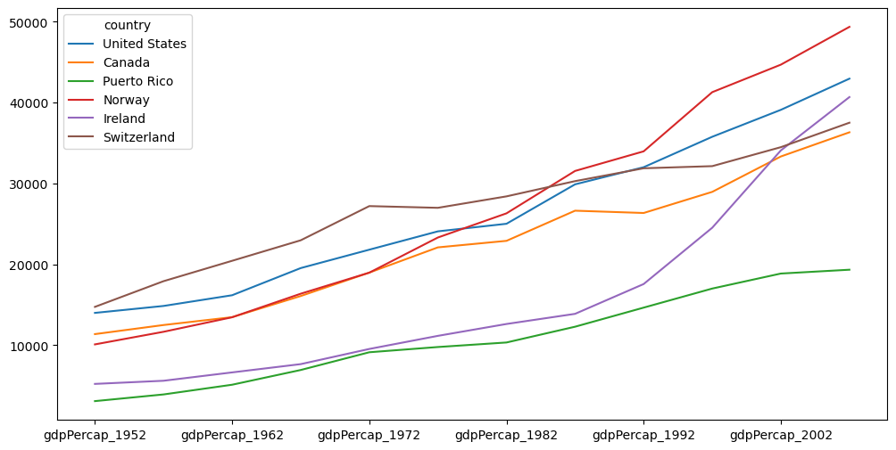

```python
fig, ax = plt.subplots(figsize=(12, 6))
rotated_df.plot(kind='line', ax=ax)
plt.show()
```

### Q11) Multiple Files

There are 5 files within the `gapminder`. Use a loop to create the dataframe `region_df` that contains a row for each region/continent that has a average for each of the gdpPerCap columns. The region/continent needs to be extracted from the filename.

```python
import os
```

```python
folder_path = 'data/gapminder/' #rel path
region_df = pd.DataFrame() #empty df

for filename in os.listdir(folder_path):
    if filename.endswith('.csv'):
        region = os.path.splitext(filename)[0].split('_')[2] # Extract the region/continent from the filename

        file_path = os.path.join(folder_path, filename) #full file path

        # Read the CSV file and append it to the region_df DataFrame
        df = pd.read_csv(file_path)
        df['Region'] = region  # Add Region column with the region/continent name
        region_df = pd.concat([region_df, df], ignore_index=True)

region_df.head(100)
```

|  | continent | country | gdpPercap_1952 | gdpPercap_1957 | gdpPercap_1962 | gdpPercap_1967 | gdpPercap_1972 | gdpPercap_1977 | gdpPercap_1982 | gdpPercap_1987 | gdpPercap_1992 | gdpPercap_1997 | gdpPercap_2002 | gdpPercap_2007 | Region |
| --- | --- | --- | --- | --- | --- | --- | --- | --- | --- | --- | --- | --- | --- | --- | --- |
| 0 | Americas | Argentina | 5911.315053 | 6856.856212 | 7133.166023 | 8052.953021 | 9443.038526 | 10079.026740 | 8997.897412 | 9139.671389 | 9308.418710 | 10967.281950 | 8797.640716 | 12779.379640 | americas |
| 1 | Americas | Bolivia | 2677.326347 | 2127.686326 | 2180.972546 | 2586.886053 | 2980.331339 | 3548.097832 | 3156.510452 | 2753.691490 | 2961.699694 | 3326.143191 | 3413.262690 | 3822.137084 | americas |
| 2 | Americas | Brazil | 2108.944355 | 2487.365989 | 3336.585802 | 3429.864357 | 4985.711467 | 6660.118654 | 7030.835878 | 7807.095818 | 6950.283021 | 7957.980824 | 8131.212843 | 9065.800825 | americas |
| 3 | Americas | Canada | 11367.161120 | 12489.950060 | 13462.485550 | 16076.588030 | 18970.570860 | 22090.883060 | 22898.792140 | 26626.515030 | 26342.884260 | 28954.925890 | 33328.965070 | 36319.235010 | americas |
| 4 | Americas | Chile | 3939.978789 | 4315.622723 | 4519.094331 | 5106.654313 | 5494.024437 | 4756.763836 | 5095.665738 | 5547.063754 | 7596.125964 | 10118.053180 | 10778.783850 | 13171.638850 | americas |
| ... | ... | ... | ... | ... | ... | ... | ... | ... | ... | ... | ... | ... | ... | ... | ... |
| 95 | NaN | Rwanda | 493.323875 | 540.289398 | 597.473073 | 510.963714 | 590.580664 | 670.080601 | 881.570647 | 847.991217 | 737.068595 | 589.944505 | 785.653765 | 863.088464 | africa |
| 96 | NaN | Sao Tome and Principe | 879.583586 | 860.736903 | 1071.551119 | 1384.840593 | 1532.985254 | 1737.561657 | 1890.218117 | 1516.525457 | 1428.777814 | 1339.076036 | 1353.092390 | 1598.435089 | africa |
| 97 | NaN | Senegal | 1450.356983 | 1567.653006 | 1654.988723 | 1612.404632 | 1597.712056 | 1561.769116 | 1518.479984 | 1441.720720 | 1367.899369 | 1392.368347 | 1519.635262 | 1712.472136 | africa |
| 98 | NaN | Sierra Leone | 879.787736 | 1004.484437 | 1116.639877 | 1206.043465 | 1353.759762 | 1348.285159 | 1465.010784 | 1294.447788 | 1068.696278 | 574.648158 | 699.489713 | 862.540756 | africa |
| 99 | NaN | Somalia | 1135.749842 | 1258.147413 | 1369.488336 | 1284.733180 | 1254.576127 | 1450.992513 | 1176.807031 | 1093.244963 | 926.960296 | 930.596428 | 882.081822 | 926.141068 | africa |

100 rows × 15 columns

```python
columns = region_df.columns.tolist() #list of columns

column = 'Region' #regions column with extracted regions/continent from filename
new_index = 0 # where the old continent column is indexed (position)

columns.remove('Region')#removes regions column from its index
columns.insert(new_index, column)
region_df = region_df.reindex(columns=columns)
region_df = region_df.drop(['continent'], axis=1)
region_df.head(100)
```

|  | Region | country | gdpPercap_1952 | gdpPercap_1957 | gdpPercap_1962 | gdpPercap_1967 | gdpPercap_1972 | gdpPercap_1977 | gdpPercap_1982 | gdpPercap_1987 | gdpPercap_1992 | gdpPercap_1997 | gdpPercap_2002 | gdpPercap_2007 |
| --- | --- | --- | --- | --- | --- | --- | --- | --- | --- | --- | --- | --- | --- | --- |
| 0 | americas | Argentina | 5911.315053 | 6856.856212 | 7133.166023 | 8052.953021 | 9443.038526 | 10079.026740 | 8997.897412 | 9139.671389 | 9308.418710 | 10967.281950 | 8797.640716 | 12779.379640 |
| 1 | americas | Bolivia | 2677.326347 | 2127.686326 | 2180.972546 | 2586.886053 | 2980.331339 | 3548.097832 | 3156.510452 | 2753.691490 | 2961.699694 | 3326.143191 | 3413.262690 | 3822.137084 |
| 2 | americas | Brazil | 2108.944355 | 2487.365989 | 3336.585802 | 3429.864357 | 4985.711467 | 6660.118654 | 7030.835878 | 7807.095818 | 6950.283021 | 7957.980824 | 8131.212843 | 9065.800825 |
| 3 | americas | Canada | 11367.161120 | 12489.950060 | 13462.485550 | 16076.588030 | 18970.570860 | 22090.883060 | 22898.792140 | 26626.515030 | 26342.884260 | 28954.925890 | 33328.965070 | 36319.235010 |
| 4 | americas | Chile | 3939.978789 | 4315.622723 | 4519.094331 | 5106.654313 | 5494.024437 | 4756.763836 | 5095.665738 | 5547.063754 | 7596.125964 | 10118.053180 | 10778.783850 | 13171.638850 |
| ... | ... | ... | ... | ... | ... | ... | ... | ... | ... | ... | ... | ... | ... | ... |
| 95 | africa | Rwanda | 493.323875 | 540.289398 | 597.473073 | 510.963714 | 590.580664 | 670.080601 | 881.570647 | 847.991217 | 737.068595 | 589.944505 | 785.653765 | 863.088464 |
| 96 | africa | Sao Tome and Principe | 879.583586 | 860.736903 | 1071.551119 | 1384.840593 | 1532.985254 | 1737.561657 | 1890.218117 | 1516.525457 | 1428.777814 | 1339.076036 | 1353.092390 | 1598.435089 |
| 97 | africa | Senegal | 1450.356983 | 1567.653006 | 1654.988723 | 1612.404632 | 1597.712056 | 1561.769116 | 1518.479984 | 1441.720720 | 1367.899369 | 1392.368347 | 1519.635262 | 1712.472136 |
| 98 | africa | Sierra Leone | 879.787736 | 1004.484437 | 1116.639877 | 1206.043465 | 1353.759762 | 1348.285159 | 1465.010784 | 1294.447788 | 1068.696278 | 574.648158 | 699.489713 | 862.540756 |
| 99 | africa | Somalia | 1135.749842 | 1258.147413 | 1369.488336 | 1284.733180 | 1254.576127 | 1450.992513 | 1176.807031 | 1093.244963 | 926.960296 | 930.596428 | 882.081822 | 926.141068 |

100 rows × 14 columns

### Q12) Plotting regional averages.

Create a line plot that showes how the average GDP per capita for each region has changed over time.

```python
avg_gdp = region_df.groupby('Region').mean()
avg_gdp = avg_gdp.T
avg_gdp
```

| Region | africa | americas | asia | europe | oceania |
| --- | --- | --- | --- | --- | --- |
| gdpPercap_1952 | 1252.572466 | 4079.062552 | 5195.484004 | 5661.057435 | 10298.085650 |
| gdpPercap_1957 | 1385.236062 | 4616.043733 | 5787.732940 | 6963.012816 | 11598.522455 |
| gdpPercap_1962 | 1598.078825 | 4901.541870 | 5729.369625 | 8365.486814 | 12696.452430 |
| gdpPercap_1967 | 2050.363801 | 5668.253496 | 5971.173374 | 10143.823757 | 14495.021790 |
| gdpPercap_1972 | 2339.615674 | 6491.334139 | 8187.468699 | 12479.575246 | 16417.333380 |
| gdpPercap_1977 | 2585.938508 | 7352.007126 | 7791.314020 | 14283.979110 | 17283.957605 |
| gdpPercap_1982 | 2481.592960 | 7506.737088 | 7434.135157 | 15617.896551 | 18554.709840 |
| gdpPercap_1987 | 2282.668991 | 7793.400261 | 7608.226508 | 17214.310727 | 20448.040160 |
| gdpPercap_1992 | 2281.810333 | 8044.934406 | 8639.690248 | 17061.568084 | 20894.045885 |
| gdpPercap_1997 | 2378.759555 | 8889.300863 | 9834.093295 | 19076.781802 | 24024.175170 |
| gdpPercap_2002 | 2599.385159 | 9287.677107 | 10174.090397 | 21711.732422 | 26938.778040 |
| gdpPercap_2007 | 3089.032605 | 11003.031625 | 12473.026870 | 25054.481636 | 29810.188275 |

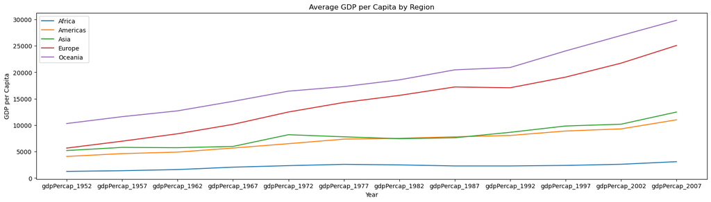

```python
import matplotlib.pyplot as plt

region_data = {
    'Year': avg_gdp.index,
    'Africa': avg_gdp['africa'],
    'Americas': avg_gdp['americas'],
    'Asia': avg_gdp['asia'],
    'Europe': avg_gdp['europe'],
    'Oceania': avg_gdp['oceania']
}
region_avg_df = pd.DataFrame(region_data)

plt.figure(figsize=(20, 5))

plt.plot(region_avg_df['Year'], region_avg_df['Africa'], label='Africa')
plt.plot(region_avg_df['Year'], region_avg_df['Americas'], label='Americas')
plt.plot(region_avg_df['Year'], region_avg_df['Asia'], label='Asia')
plt.plot(region_avg_df['Year'], region_avg_df['Europe'], label='Europe')
plt.plot(region_avg_df['Year'], region_avg_df['Oceania'], label='Oceania')

plt.title('Average GDP per Capita by Region')
plt.xlabel('Year')
plt.ylabel('GDP per Capita')

plt.legend()

plt.show()
```

## Section 2: Capital Bikeshare Rides and Weather

Capital Bikeshare Data: In the `captialbikeshare` folder. https://capitalbikeshare.com/system-data

Data Description:

- Duration – Duration of trip
- Start Date – Includes start date and time
- End Date – Includes end date and time
- Start Station – Includes starting station name and number
- End Station – Includes ending station name and number
- Bike Number – Includes ID number of bike used for the trip
- Member Type – Indicates whether user was a "registered" member (Annual Member, 30-Day Member or Day Key Member) or a "casual" rider (Single Trip, 24-Hour Pass, 3-Day Pass)

Weather Data: `arboretum_weather_2022.csv` (Climate Data Online: https://www.ncei.noaa.gov/cdo-web/)

Data Description:

- DAPR - Number of days included in the multiday precipitation total (MDPR)
- SNOW - Snowfall
- WT11 - High or damaging winds
- WT01 - Fog, ice fog, or freezing fog (may include heavy fog)
- TMAX - Maximum temperature
- WESD - Water equivalent of snow on the ground
- TMIN - Minimum temperature
- PRCP - Precipitation
- TOBS - Temperature at the time of observation
- MDPR - Multiday precipitation total (use with DAPR and DWPR, if available)
- SNWD - Snow depth

### Goal of Analysis

The analytical goal of this section is to be able to predict the number of daily rides based on the weather.

### Q13) Import the Capital Bikeshare Data

Inside the `data/capitalbikeshare/` folder there are 3 data files. Import them into a single dataframe named `bikeshare_df`. Make sure that you use **relative** paths and that you use a loop to import the files. You should not have to hard code any file names.

```python
import os
path = 'data/capitalbikeshare/'
files = []

for filename in os.listdir(path):
    if filename.endswith('.csv'):
        filepath = os.path.join(path, filename)

        # Read the CSV file into df
        bike_dfs = pd.read_csv(filepath)

        # Append the dataframe to the list
        files.append(bike_dfs)

        #concat dfs into dataframe
        bikeshare_df = pd.concat(files)
```

```python
bikeshare_df.shape
```

```
(1160996, 13)
```

```python
bikeshare_df.head(5)
```

|  | ride_id | rideable_type | started_at | ended_at | start_station_name | start_station_id | end_station_name | end_station_id | start_lat | start_lng | end_lat | end_lng | member_casual |
| --- | --- | --- | --- | --- | --- | --- | --- | --- | --- | --- | --- | --- | --- |
| 0 | 7E4A3A88DA791628 | classic_bike | 2022-06-21 07:12:11 | 2022-06-21 07:15:20 | Long Bridge Aquatic Center | 31950.0 | Long Bridge Park / Long Bridge Dr & 6th St S | 31090.0 | 38.870561 | -77.044095 | 38.865553 | -77.050030 | member |
| 1 | 9D05B4C81F3686B4 | classic_bike | 2022-06-29 15:01:20 | 2022-06-29 16:07:36 | 8th & Eye St SE / Barracks Row | 31608.0 | Jefferson Dr & 14th St SW | 31247.0 | 38.879200 | -76.995300 | 38.888553 | -77.032427 | member |
| 2 | 0D0280428308DAD8 | docked_bike | 2022-06-17 20:19:19 | 2022-06-17 20:42:48 | Potomac Ave & Half St SW | 31648.0 | Eastern Market Metro / Pennsylvania Ave & 8th ... | 31613.0 | 38.869683 | -77.010815 | 38.884095 | -76.995234 | casual |
| 3 | 76DA5E125917F688 | docked_bike | 2022-06-24 17:19:25 | 2022-06-24 18:30:43 | Potomac Ave & 35th St S | 31052.0 | S Clark St & 33rd St | 31944.0 | 38.844015 | -77.050537 | 38.845028 | -77.051956 | casual |
| 4 | BFEF6DFC09107A32 | classic_bike | 2022-06-02 13:01:02 | 2022-06-02 14:05:56 | 8th & Eye St SE / Barracks Row | 31608.0 | Good Hope Rd & MLK Ave SE | 31802.0 | 38.879200 | -76.995300 | 38.867373 | -76.988039 | casual |

### Q14) Ensure that the `bikeshare_df` dataframe is ready for analysis.

Verify that your data imported correctly and "clean" the data as needed.

```python
bikeshare_df.dtypes
```

```
ride_id                object
rideable_type          object
started_at             object
ended_at               object
start_station_name     object
start_station_id      float64
end_station_name       object
end_station_id        float64
start_lat             float64
start_lng             float64
end_lat               float64
end_lng               float64
member_casual          object
dtype: object
```

```python
import pandas as pd

#convert times to date times
bikeshare_df['started_at'] = pd.to_datetime(bikeshare_df['started_at'])
bikeshare_df['ended_at'] = pd.to_datetime(bikeshare_df['ended_at'])
bikeshare_df['start_time'] = bikeshare_df['started_at'].dt.strftime('%H:%M:%S')
bikeshare_df['end_time'] = bikeshare_df['ended_at'].dt.strftime('%H:%M:%S')
bikeshare_df['date'] = bikeshare_df['started_at'].dt.strftime('%Y-%m-%d')
```

```python
columns = bikeshare_df.columns.tolist() #list of columns

column_one = 'date'
column_two = 'start_time'
column_three = 'end_time'

new_index = 3 # where the old continent column is indexed (position)
new_index_v2 = 4
new_index_v3 = 5

columns.remove('date')#removes date column from its index
columns.remove('start_time')#removes start_time column from its index
columns.remove('end_time')#removes end_time column from its index

columns.insert(new_index, column_one)
columns.insert(new_index_v2, column_two)
columns.insert(new_index_v3, column_three)

bikeshare_df = bikeshare_df.reindex(columns=columns)

bikeshare_df = bikeshare_df.drop(columns=['started_at', 'ended_at'], axis=1)
bikeshare_df.head()
```

|  | ride_id | rideable_type | date | start_time | end_time | start_station_name | start_station_id | end_station_name | end_station_id | start_lat | start_lng | end_lat | end_lng | member_casual |
| --- | --- | --- | --- | --- | --- | --- | --- | --- | --- | --- | --- | --- | --- | --- |
| 0 | 7E4A3A88DA791628 | classic_bike | 2022-06-21 | 07:12:11 | 07:15:20 | Long Bridge Aquatic Center | 31950.0 | Long Bridge Park / Long Bridge Dr & 6th St S | 31090.0 | 38.870561 | -77.044095 | 38.865553 | -77.050030 | member |
| 1 | 9D05B4C81F3686B4 | classic_bike | 2022-06-29 | 15:01:20 | 16:07:36 | 8th & Eye St SE / Barracks Row | 31608.0 | Jefferson Dr & 14th St SW | 31247.0 | 38.879200 | -76.995300 | 38.888553 | -77.032427 | member |
| 2 | 0D0280428308DAD8 | docked_bike | 2022-06-17 | 20:19:19 | 20:42:48 | Potomac Ave & Half St SW | 31648.0 | Eastern Market Metro / Pennsylvania Ave & 8th ... | 31613.0 | 38.869683 | -77.010815 | 38.884095 | -76.995234 | casual |
| 3 | 76DA5E125917F688 | docked_bike | 2022-06-24 | 17:19:25 | 18:30:43 | Potomac Ave & 35th St S | 31052.0 | S Clark St & 33rd St | 31944.0 | 38.844015 | -77.050537 | 38.845028 | -77.051956 | casual |
| 4 | BFEF6DFC09107A32 | classic_bike | 2022-06-02 | 13:01:02 | 14:05:56 | 8th & Eye St SE / Barracks Row | 31608.0 | Good Hope Rd & MLK Ave SE | 31802.0 | 38.879200 | -76.995300 | 38.867373 | -76.988039 | casual |

### Q15) Explain your cleaning steps.

Explain the steps that you took to clean your data and why you believe that your data is ready for analysis.

**Use the markdown cell below to answer this question.**

**First, I reviewed the dataframes' datatypes to ensure that each column was in proper formatting. The decimal values were floats, the id's containing numbers and letters were objects, the names were strings, and other numerical ids were counted as float ints which was good and standard.**

**However, I noticed that the columns "started_at" and "ended_at" had date, and time as its values-- presented as an object. Therefore, I converted the columns into datetimes, and to make things easier I created separated columns for date, start time and end time and extracted the values from the old columns to populate the new ones I made.**

**The column names seemed fine to me, the datatypes are now correct, and the columns were formatted through dropping and moving columns over. It is ready for analysis in my estimation.**

### Q16) Create a new column named `length` that contains the length of each ride.

```python
bikeshare_df.dtypes
```

```
ride_id                object
rideable_type          object
date                   object
start_time             object
end_time               object
start_station_name     object
start_station_id      float64
end_station_name       object
end_station_id        float64
start_lat             float64
start_lng             float64
end_lat               float64
end_lng               float64
member_casual          object
dtype: object
```

```python
bikeshare_df['start_time'] = pd.to_datetime(bikeshare_df['start_time'])
bikeshare_df['end_time'] = pd.to_datetime(bikeshare_df['end_time'])
bikeshare_df['length'] = bikeshare_df['end_time'] - bikeshare_df['start_time']
bikeshare_df.head(2)
```

|  | ride_id | rideable_type | date | start_time | end_time | start_station_name | start_station_id | end_station_name | end_station_id | start_lat | start_lng | end_lat | end_lng | member_casual | length |
| --- | --- | --- | --- | --- | --- | --- | --- | --- | --- | --- | --- | --- | --- | --- | --- |
| 0 | 7E4A3A88DA791628 | classic_bike | 2022-06-21 | 2023-05-14 07:12:11 | 2023-05-14 07:15:20 | Long Bridge Aquatic Center | 31950.0 | Long Bridge Park / Long Bridge Dr & 6th St S | 31090.0 | 38.870561 | -77.044095 | 38.865553 | -77.050030 | member | 0 days 00:03:09 |
| 1 | 9D05B4C81F3686B4 | classic_bike | 2022-06-29 | 2023-05-14 15:01:20 | 2023-05-14 16:07:36 | 8th & Eye St SE / Barracks Row | 31608.0 | Jefferson Dr & 14th St SW | 31247.0 | 38.879200 | -76.995300 | 38.888553 | -77.032427 | member | 0 days 01:06:16 |

### Q17) Convert the ride_length column to minutes

The `length` column is currently a timedelta object. Convert it to minutes. Colunm change the column's name to show that the value is in minutes.

*Hint:* Just like you can access string functions by using `str` on a Series, you can use the `dt` accessor to get the `seconds`.

```python
from datetime import timedelta

def timedelta_to_minutes(td):
    return td.total_seconds() / 60 #convert to seconds, divide by 60; 60 secs = 1 min

bikeshare_df['length'] = bikeshare_df['length'].apply(timedelta_to_minutes) #apply function created

bikeshare_df
```

|  | ride_id | rideable_type | date | start_time | end_time | start_station_name | start_station_id | end_station_name | end_station_id | start_lat | start_lng | end_lat | end_lng | member_casual | length |
| --- | --- | --- | --- | --- | --- | --- | --- | --- | --- | --- | --- | --- | --- | --- | --- |
| 0 | 7E4A3A88DA791628 | classic_bike | 2022-06-21 | 2023-05-14 07:12:11 | 2023-05-14 07:15:20 | Long Bridge Aquatic Center | 31950.0 | Long Bridge Park / Long Bridge Dr & 6th St S | 31090.0 | 38.870561 | -77.044095 | 38.865553 | -77.050030 | member | 3.150000 |
| 1 | 9D05B4C81F3686B4 | classic_bike | 2022-06-29 | 2023-05-14 15:01:20 | 2023-05-14 16:07:36 | 8th & Eye St SE / Barracks Row | 31608.0 | Jefferson Dr & 14th St SW | 31247.0 | 38.879200 | -76.995300 | 38.888553 | -77.032427 | member | 66.266667 |
| 2 | 0D0280428308DAD8 | docked_bike | 2022-06-17 | 2023-05-14 20:19:19 | 2023-05-14 20:42:48 | Potomac Ave & Half St SW | 31648.0 | Eastern Market Metro / Pennsylvania Ave & 8th ... | 31613.0 | 38.869683 | -77.010815 | 38.884095 | -76.995234 | casual | 23.483333 |
| 3 | 76DA5E125917F688 | docked_bike | 2022-06-24 | 2023-05-14 17:19:25 | 2023-05-14 18:30:43 | Potomac Ave & 35th St S | 31052.0 | S Clark St & 33rd St | 31944.0 | 38.844015 | -77.050537 | 38.845028 | -77.051956 | casual | 71.300000 |
| 4 | BFEF6DFC09107A32 | classic_bike | 2022-06-02 | 2023-05-14 13:01:02 | 2023-05-14 14:05:56 | 8th & Eye St SE / Barracks Row | 31608.0 | Good Hope Rd & MLK Ave SE | 31802.0 | 38.879200 | -76.995300 | 38.867373 | -76.988039 | casual | 64.900000 |
| ... | ... | ... | ... | ... | ... | ... | ... | ... | ... | ... | ... | ... | ... | ... | ... |
| 377652 | D7C52CFA72381BAB | classic_bike | 2022-08-06 | 2023-05-14 22:28:58 | 2023-05-14 22:45:07 | 20th St & Florida Ave NW | 31110.0 | New Jersey Ave & N St NW/Dunbar HS | 31636.0 | 38.915400 | -77.044600 | 38.907333 | -77.015360 | member | 16.150000 |
| 377653 | 7D77BCB874F264EA | classic_bike | 2022-08-17 | 2023-05-14 17:01:21 | 2023-05-14 17:06:50 | Maryland Ave & 17th St NE | 31656.0 | 13th & H St NE | 31611.0 | 38.901935 | -76.978627 | 38.900427 | -76.988250 | member | 5.483333 |
| 377654 | E684FCA6183F89DA | classic_bike | 2022-08-22 | 2023-05-14 13:01:53 | 2023-05-14 13:22:28 | Maryland Ave & 17th St NE | 31656.0 | 11th & Girard St NW | 31126.0 | 38.901935 | -76.978627 | 38.925636 | -77.027112 | member | 20.583333 |
| 377655 | 20813AED8ADC5BCF | classic_bike | 2022-08-31 | 2023-05-14 20:08:33 | 2023-05-14 20:18:27 | 15th St & Pennsylvania Ave NW | 31129.0 | 4th & E St SW | 31244.0 | 38.896465 | -77.033381 | 38.884120 | -77.017445 | member | 9.900000 |
| 377656 | 2D3512C399F3E7FF | classic_bike | 2022-08-30 | 2023-05-14 16:13:39 | 2023-05-14 16:17:06 | 7th & K St NW | 31653.0 | New Jersey Ave & N St NW/Dunbar HS | 31636.0 | 38.902674 | -77.021392 | 38.907333 | -77.015360 | member | 3.450000 |

1160996 rows × 15 columns

```python
bikeshare_df['date'] = pd.to_datetime(bikeshare_df['date'])
```

```python
bikeshare_df.dtypes
```

```
ride_id                       object
rideable_type                 object
date                  datetime64[ns]
start_time            datetime64[ns]
end_time              datetime64[ns]
start_station_name            object
start_station_id             float64
end_station_name              object
end_station_id               float64
start_lat                    float64
start_lng                    float64
end_lat                      float64
end_lng                      float64
member_casual                 object
length                       float64
dtype: object
```

### Q18) Import and clean the weather data.

The weather data is in the file `data/arboretum_weather_2022.csv`. Import this file into a dataframe named `weather_df`. Make sure that you use **relative** paths. You should perform all of the "cleaning" required to prepare the data for the next step.

```python
path = 'data/arboretum_weather_2022.csv'
weather_df = pd.read_csv(path)
weather_df
```

|  | STATION | NAME | DATE | DAPR | MDPR | PRCP | SNOW | SNWD | TMAX | TMIN | TOBS | WESD | WT01 | WT11 |
| --- | --- | --- | --- | --- | --- | --- | --- | --- | --- | --- | --- | --- | --- | --- |
| 0 | USC00186350 | NATIONAL ARBORETUM DC, MD US | 2022-01-01 | NaN | NaN | 0.15 | 0.0 | 0.0 | 59.0 | 52.0 | 58.0 | NaN | NaN | NaN |
| 1 | USC00186350 | NATIONAL ARBORETUM DC, MD US | 2022-01-02 | NaN | NaN | 0.44 | 0.0 | 0.0 | 64.0 | 56.0 | 58.0 | NaN | NaN | NaN |
| 2 | USC00186350 | NATIONAL ARBORETUM DC, MD US | 2022-01-04 | 2.0 | 1.39 | NaN | 7.4 | 7.0 | NaN | NaN | 34.0 | NaN | NaN | NaN |
| 3 | USC00186350 | NATIONAL ARBORETUM DC, MD US | 2022-01-06 | NaN | NaN | 0.00 | 0.0 | NaN | NaN | NaN | 31.0 | NaN | NaN | NaN |
| 4 | USC00186350 | NATIONAL ARBORETUM DC, MD US | 2022-01-07 | NaN | NaN | 0.18 | 1.0 | 3.0 | 46.0 | 21.0 | 22.0 | NaN | NaN | NaN |
| ... | ... | ... | ... | ... | ... | ... | ... | ... | ... | ... | ... | ... | ... | ... |
| 316 | USC00186350 | NATIONAL ARBORETUM DC, MD US | 2022-11-26 | NaN | NaN | 0.01 | 0.0 | 0.0 | 64.0 | 36.0 | 45.0 | NaN | NaN | NaN |
| 317 | USC00186350 | NATIONAL ARBORETUM DC, MD US | 2022-11-27 | NaN | NaN | 0.00 | 0.0 | 0.0 | 60.0 | 40.0 | 52.0 | NaN | NaN | NaN |
| 318 | USC00186350 | NATIONAL ARBORETUM DC, MD US | 2022-11-28 | NaN | NaN | 0.25 | 0.0 | 0.0 | 59.0 | 48.0 | 56.0 | NaN | NaN | NaN |
| 319 | USC00186350 | NATIONAL ARBORETUM DC, MD US | 2022-11-29 | NaN | NaN | 0.00 | 0.0 | 0.0 | 58.0 | 33.0 | 41.0 | NaN | NaN | NaN |
| 320 | USC00186350 | NATIONAL ARBORETUM DC, MD US | 2022-11-30 | NaN | NaN | 0.30 | 0.0 | 0.0 | 58.0 | 33.0 | 51.0 | NaN | NaN | NaN |

321 rows × 14 columns

```python
weather_df.dtypes
```

```
STATION     object
NAME        object
DATE        object
DAPR       float64
MDPR       float64
PRCP       float64
SNOW       float64
SNWD       float64
TMAX       float64
TMIN       float64
TOBS       float64
WESD       float64
WT01       float64
WT11       float64
dtype: object
```

```python
#convert date from an object to datetime datatype
weather_df['DATE'] = pd.to_datetime(weather_df['DATE'])
```

```python
weather_df.dtypes #see changes reflected DATE = datetime64[ns]
```

```
STATION            object
NAME               object
DATE       datetime64[ns]
DAPR              float64
MDPR              float64
PRCP              float64
SNOW              float64
SNWD              float64
TMAX              float64
TMIN              float64
TOBS              float64
WESD              float64
WT01              float64
WT11              float64
dtype: object
```

### Q19) Impute the missing weather data.

Our preference is always to leave missing values alone, but our analysis requires that we have a value for each day. Identify the 4 methods for estimating and imputing missing values and explain which method you will use and why. Assume that you have performed the appropriate diagnosis and determined that the missing values are missing completely at random (MCAR).

We only need the values in the following columns:

- TMAX: Maximum temperature
- TMIN: Minimum temperature
- PRCP: Amount of precipitation (in inches)

Explain your answer in the markdown cell below and in the code cell write the code to implement your method.

```python
#imputation through interpolation
weather_df['TMAX'].interpolate(inplace=True)
weather_df['TMIN'].interpolate(inplace=True)
weather_df['PRCP'].interpolate(inplace=True)

#clean df, only need tmax, tmin, prcp

columns = ['STATION', 'NAME', 'DAPR', 'MDPR', 'SNOW', 'SNWD', 'TOBS', 'WESD', 'WT01', 'WT11']
weather_df = weather_df.drop(columns, axis=1)

weather_df.head(5)
```

|  | DATE | PRCP | TMAX | TMIN |
| --- | --- | --- | --- | --- |
| 0 | 2022-01-01 | 0.15 | 59.0 | 52.000000 |
| 1 | 2022-01-02 | 0.44 | 64.0 | 56.000000 |
| 2 | 2022-01-04 | 0.22 | 58.0 | 44.333333 |
| 3 | 2022-01-06 | 0.00 | 52.0 | 32.666667 |
| 4 | 2022-01-07 | 0.18 | 46.0 | 21.000000 |

```python
weather_df.dtypes
```

```
DATE    datetime64[ns]
PRCP           float64
TMAX           float64
TMIN           float64
dtype: object
```

### Q20) Data Integration and Data Fusion

You should have noticed that the two datasets are at different levels of analysis. The rides data is at the level of individual rides while the weather data is at the daily level. In order to merge the two datasets, we will need to get them to be at the same level of analysis.

Is this considered data integration or data fusion? Explain your answer.

**Use the markdown cell below to answer this question.**

**The merge of bikeshare data and weather data could be classified as data fusion. In this situation, we could merge the bikeshare data and weather data to gain insights on whether weather has an impact on bike rides such as ride time spent (duration of ride), ride distance, common start or end stations, frequency of bike rides in the day and more. Essentially, this type of analysis wouldn't be possible alone without the combination of these two datasets that actually appear to have a correlation when combined.**

### Q21) Prepare the rides_df data to be merged with the weather_df data.

Aggregate the rides data so that it shows us the total number of rides per day and the average length of rides. The dataframe should contain the following columns:

- date (derived from the `started_at` column)
- member_type
- number_of_rides
- avg_length_min

You will likely need to `reset_index` in order to rename the columns. The `date` column must be a datetime and not a string. You should also set the index to be the date.

```python
print(bikeshare_df.columns)
```

```
Index(['ride_id', 'rideable_type', 'date', 'start_time', 'end_time',
       'start_station_name', 'start_station_id', 'end_station_name',
       'end_station_id', 'start_lat', 'start_lng', 'end_lat', 'end_lng',
       'member_casual', 'length'],
      dtype='object')
```

```python
bikeshare_df.dtypes
```

```
ride_id                       object
rideable_type                 object
date                  datetime64[ns]
start_time            datetime64[ns]
end_time              datetime64[ns]
start_station_name            object
start_station_id             float64
end_station_name              object
end_station_id               float64
start_lat                    float64
start_lng                    float64
end_lat                      float64
end_lng                      float64
member_casual                 object
length                       float64
dtype: object
```

```python
bikeshare_df.shape #check columns and rows (shape)
```

```
(1160996, 15)
```

```python
import pandas as pd

bikeshare_df.set_index('date', inplace=True)
rides_date = bikeshare_df.groupby(bikeshare_df.index.date).size()

bikeshare_df['number_of_rides'] = rides_date

avg_length_min = bikeshare_df.groupby('date')['length'].mean()

#avg_length_min = bikeshare_df['length'].mean()

bikeshare_df['avg_length_min'] = avg_length_min

##finding the average length was tricky as you can see I have another code commented out, the commented out code
#gave me a value that was present throughout the entire column and it just did not seem right to me.
```

```python
bikeshare_df.rename(columns={'member_casual': 'member_type'}, inplace=True)
rides_df = bikeshare_df
rides_df.head(100)
```

| date | ride_id | rideable_type | start_time | end_time | start_station_name | start_station_id | end_station_name | end_station_id | start_lat | start_lng | end_lat | end_lng | member_type | length | number_of_rides | avg_length_min |
| --- | --- | --- | --- | --- | --- | --- | --- | --- | --- | --- | --- | --- | --- | --- | --- | --- |
| 2022-06-21 | 7E4A3A88DA791628 | classic_bike | 2023-05-14 07:12:11 | 2023-05-14 07:15:20 | Long Bridge Aquatic Center | 31950.0 | Long Bridge Park / Long Bridge Dr & 6th St S | 31090.0 | 38.870561 | -77.044095 | 38.865553 | -77.050030 | member | 3.150000 | 12891 | 13.859116 |
| 2022-06-29 | 9D05B4C81F3686B4 | classic_bike | 2023-05-14 15:01:20 | 2023-05-14 16:07:36 | 8th & Eye St SE / Barracks Row | 31608.0 | Jefferson Dr & 14th St SW | 31247.0 | 38.879200 | -76.995300 | 38.888553 | -77.032427 | member | 66.266667 | 13486 | 12.412765 |
| 2022-06-17 | 0D0280428308DAD8 | docked_bike | 2023-05-14 20:19:19 | 2023-05-14 20:42:48 | Potomac Ave & Half St SW | 31648.0 | Eastern Market Metro / Pennsylvania Ave & 8th ... | 31613.0 | 38.869683 | -77.010815 | 38.884095 | -76.995234 | casual | 23.483333 | 13012 | -4.301455 |
| 2022-06-24 | 76DA5E125917F688 | docked_bike | 2023-05-14 17:19:25 | 2023-05-14 18:30:43 | Potomac Ave & 35th St S | 31052.0 | S Clark St & 33rd St | 31944.0 | 38.844015 | -77.050537 | 38.845028 | -77.051956 | casual | 71.300000 | 15249 | 8.885116 |
| 2022-06-02 | BFEF6DFC09107A32 | classic_bike | 2023-05-14 13:01:02 | 2023-05-14 14:05:56 | 8th & Eye St SE / Barracks Row | 31608.0 | Good Hope Rd & MLK Ave SE | 31802.0 | 38.879200 | -76.995300 | 38.867373 | -76.988039 | casual | 64.900000 | 8502 | 14.351376 |
| ... | ... | ... | ... | ... | ... | ... | ... | ... | ... | ... | ... | ... | ... | ... | ... | ... |
| 2022-06-01 | F668392570770215 | classic_bike | 2023-05-14 17:14:09 | 2023-05-14 17:32:00 | 6th St & Indiana Ave NW | 31264.0 | 16th & R St NW | 31282.0 | 38.894573 | -77.019940 | 38.912652 | -77.036278 | member | 17.850000 | 11370 | 12.426756 |
| 2022-06-14 | 13C0B654E80700BF | classic_bike | 2023-05-14 22:19:25 | 2023-05-14 23:46:27 | Wilson Blvd & Ft Myer Dr | 31015.0 | Wilson Blvd & Ft Myer Dr | 31015.0 | 38.894600 | -77.072305 | 38.894600 | -77.072305 | casual | 87.033333 | 12794 | 12.637408 |
| 2022-06-15 | 7968EB62BD5465E2 | classic_bike | 2023-05-14 07:58:37 | 2023-05-14 08:03:59 | Wilson Blvd & Ft Myer Dr | 31015.0 | Wilson Blvd & Ft Myer Dr | 31015.0 | 38.894600 | -77.072305 | 38.894600 | -77.072305 | casual | 5.366667 | 13427 | 11.718161 |
| 2022-06-22 | BEDFB76B5CCD9D21 | classic_bike | 2023-05-14 12:07:49 | 2023-05-14 12:39:40 | South Gate Community Center | 32250.0 | South Gate Community Center | 32250.0 | 38.941496 | -77.366499 | 38.941496 | -77.366499 | casual | 31.850000 | 10140 | 13.588690 |
| 2022-06-16 | C60B7185EBC12CF4 | classic_bike | 2023-05-14 15:27:36 | 2023-05-14 15:43:32 | 4th & D St NW / Judiciary Square | 31621.0 | 18th & C St NW | 31284.0 | 38.895344 | -77.016106 | 38.893511 | -77.041544 | member | 15.933333 | 12793 | 6.867171 |

100 rows × 16 columns

```python
columns = ['ride_id', 'rideable_type', 'start_time', 'end_time',
       'start_station_name', 'start_station_id', 'end_station_name',
       'end_station_id', 'start_lat', 'start_lng', 'end_lat', 'end_lng','length']

rides_df = rides_df.drop(columns, axis=1)
rides_df
```

| date | member_type | number_of_rides | avg_length_min |
| --- | --- | --- | --- |
| 2022-06-21 | member | 12891 | 13.859116 |
| 2022-06-29 | member | 13486 | 12.412765 |
| 2022-06-17 | casual | 13012 | -4.301455 |
| 2022-06-24 | casual | 15249 | 8.885116 |
| 2022-06-02 | casual | 8502 | 14.351376 |
| ... | ... | ... | ... |
| 2022-08-06 | member | 14686 | 15.162566 |
| 2022-08-17 | member | 12822 | 15.775430 |
| 2022-08-22 | member | 10138 | 14.028354 |
| 2022-08-31 | member | 13265 | 11.889734 |
| 2022-08-30 | member | 10008 | 11.236218 |

1160996 rows × 3 columns

### Q22) Merge the weather and rides data.

Merge the weather and rides dataframes into a single dataframe named `merged_df`. The resulting dataframe should have only the following columns (you may need to drop or rename columns):

- member_type
- number_of_rides
- avg_length_min
- precipitation
- max_temp
- min_temp

```python
#rename columns as asked in question
weather_df.rename(columns={'DATE': 'date', 'PRCP': 'precipitation', 'TMAX': 'max_temp', 'TMIN': 'min_temp'}, inplace=True)
weather_df
```

|  | date | precipitation | max_temp | min_temp |
| --- | --- | --- | --- | --- |
| 0 | 2022-01-01 | 0.15 | 59.0 | 52.000000 |
| 1 | 2022-01-02 | 0.44 | 64.0 | 56.000000 |
| 2 | 2022-01-04 | 0.22 | 58.0 | 44.333333 |
| 3 | 2022-01-06 | 0.00 | 52.0 | 32.666667 |
| 4 | 2022-01-07 | 0.18 | 46.0 | 21.000000 |
| ... | ... | ... | ... | ... |
| 316 | 2022-11-26 | 0.01 | 64.0 | 36.000000 |
| 317 | 2022-11-27 | 0.00 | 60.0 | 40.000000 |
| 318 | 2022-11-28 | 0.25 | 59.0 | 48.000000 |
| 319 | 2022-11-29 | 0.00 | 58.0 | 33.000000 |
| 320 | 2022-11-30 | 0.30 | 58.0 | 33.000000 |

321 rows × 4 columns

```python
#merge on date (common key)
merged_df = pd.merge(rides_df, weather_df, on='date', how='left')
merged_df
```

|  | date | member_type | number_of_rides | avg_length_min | precipitation | max_temp | min_temp |
| --- | --- | --- | --- | --- | --- | --- | --- |
| 0 | 2022-06-21 | member | 12891 | 13.859116 | 0.00 | 82.0 | 53.0 |
| 1 | 2022-06-29 | member | 13486 | 12.412765 | 0.00 | 83.0 | 61.0 |
| 2 | 2022-06-17 | casual | 13012 | -4.301455 | 0.00 | 86.0 | 69.0 |
| 3 | 2022-06-24 | casual | 15249 | 8.885116 | 0.10 | 73.0 | 62.0 |
| 4 | 2022-06-02 | casual | 8502 | 14.351376 | 0.00 | 94.0 | 71.0 |
| ... | ... | ... | ... | ... | ... | ... | ... |
| 1160991 | 2022-08-06 | member | 14686 | 15.162566 | 1.99 | 91.0 | 74.0 |
| 1160992 | 2022-08-17 | member | 12822 | 15.775430 | 0.00 | 83.0 | 62.0 |
| 1160993 | 2022-08-22 | member | 10138 | 14.028354 | 1.07 | 81.0 | 72.0 |
| 1160994 | 2022-08-31 | member | 13265 | 11.889734 | 0.21 | 93.0 | 68.0 |
| 1160995 | 2022-08-30 | member | 10008 | 11.236218 | 0.00 | 93.0 | 73.0 |

1160996 rows × 7 columns

### Q23) Compairing populations - Number of Rides

Use a visualizaiton technique to compare the number of rides for each type of rider. Be sure to include a title, axis labels, and a legend.

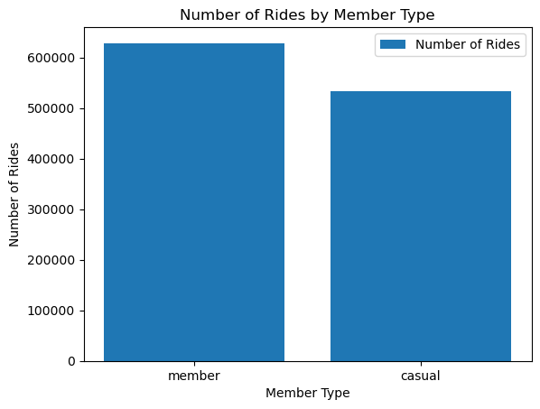

```python
import matplotlib.pyplot as plt
ride_type = merged_df['member_type'].value_counts()

plt.bar(ride_type.index, ride_type.values)

plt.xlabel('Member Type')
plt.ylabel('Number of Rides')
plt.title('Number of Rides by Member Type')
plt.legend(['Number of Rides'])
plt.show()
```

### Q24) Compairing populations - Average Length

Use a visualizaiton technique to compare the average length of rides for each type of rider. Be sure to include a title, axis labels, and a legend.

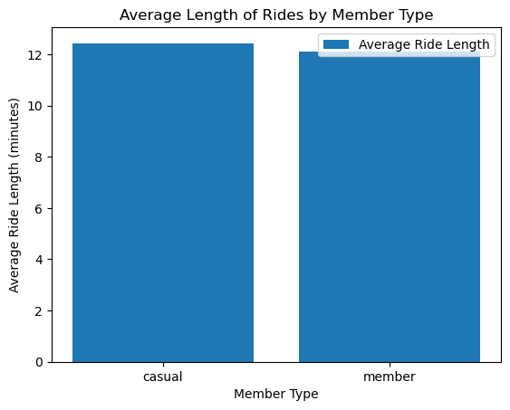

```python
avg_time = merged_df.groupby('member_type')['avg_length_min'].mean()
plt.bar(avg_time.index, avg_time.values)
plt.xlabel('Member Type')
plt.ylabel('Average Ride Length (minutes)')
plt.title('Average Length of Rides by Member Type')
plt.legend(['Average Ride Length'])
plt.show()
```

### Q25) Is there a relationship between the weather and the number of rides?

Out of the variables in the `merged_df` dataframe, perform an analysis that will help us understand if there is a relationship between the weather and the number of rides. Explain your findings.

```python
var_test = ['number_of_rides', 'precipitation', 'max_temp', 'min_temp']
corr = merged_df[var_test].corr()
corr
```

|  | number_of_rides | precipitation | max_temp | min_temp |
| --- | --- | --- | --- | --- |
| number_of_rides | 1.000000 | -0.013955 | -0.216630 | -0.338678 |
| precipitation | -0.013955 | 1.000000 | 0.133314 | 0.169724 |
| max_temp | -0.216630 | 0.133314 | 1.000000 | 0.605009 |
| min_temp | -0.338678 | 0.169724 | 0.605009 | 1.000000 |

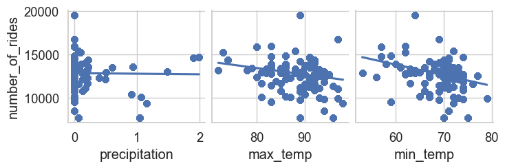

```python
import seaborn as sns
import matplotlib.pyplot as plt

sns.set(style="whitegrid", font_scale=1.2)
sns.pairplot(data=merged_df, y_vars='number_of_rides', x_vars=var_test[1:], kind='reg')
plt.show()
```

**In conclusion, there seems to be a negatively weak to moderate relationship between number of rides and the weather variables. In actuality, I could see how weather may impact the number of rides taken in a day. It would be logical if there was an increase in bikeshare use during warmer weather and climates versus colder ones. In addition, I could see how weather like rain or snow could reduce the likelihood of using bikeshare services and even significantly decrease the duration of trips. Unfortunately, this is analysis I hoped to represent in my models, however, the dataframes were limited and more variables and factors would have to be involved.**